# **Medicare Hospitals Geography Service 2013-2022**

# Overview

Introduction to dataset:

The dataset showcases information regarding geographical area, diagnoses, discharges, average billing charges, average patient payment amounts, and average medicare payment amount.

Pupose of this notebook:

this notebook will use 4 visualizations including line plots, bar plots, histograms, and scatter plots with the use of 6 filters with interactive features to overall support the analysis of these items.

Purpose of analysis:

During this analysis, I aim to analyze trends in hospital discharges overtime, explore comparisons across payments and diagnoses, as well as evaluate distibutions and relationships between payment amounts and discharges.

# Data loading and preprocessing

I downloaded the dataset and ensured that the column names were consistent and began to prepare for the creation of data visualizations.

```python
# download the required libraries
!pip install -q panel==1.6.0 bokeh==3.6.3 matplotlib==3.10.0 pandas==2.2.2 numpy==2.0.2 jupyter_bokeh==4.0.5 seaborn==0.13.2 mplcursors==0.5
```

```python
# import and activate extentions
import panel as pn
import pandas as pd
import matplotlib.pyplot as plt
import seaborn as sns

# make sure this extension is implemented ensure interactives work
pn.extension()
```

```python
# install gdown
!pip install gdown
# install dataset using Google Drive file ID
!gdown --id 1GC1Ra31P25pz_0973tV_WrMcHpmssy0e --output "Medicare Hospitals Geography Service 2013-2022.csv"
```

```
Downloading...
From: https://drive.google.com/uc?id=1GC1Ra31P25pz_0973tV_WrMcHpmssy0e
To: /content/Medicare Hospitals Geography Service 2013-2022.csv
100% 34.0M/34.0M [00:00<00:00, 164MB/s]
```

```python
# load and preview dataset
import pandas as pd
df = pd.read_csv("Medicare Hospitals Geography Service 2013-2022.csv")
df.head(10)
```

|  | Year | Rndrng_Prvdr_Geo_Lvl | Rndrng_Prvdr_Geo_Cd | Rndrng_Prvdr_Geo_Desc | DRG_Cd | DRG_Desc | Tot_Dschrgs | Avg_Submtd_Cvrd_Chrg | Avg_Tot_Pymt_Amt | Avg_Mdcr_Pymt_Amt |
| --- | --- | --- | --- | --- | --- | --- | --- | --- | --- | --- |
| 0 | 2013 | National | NaN | National | 1 | HEART TRANSPLANT OR IMPLANT OF HEART ASSIST SY... | 1619 | 843946.20074 | 256885.023470 | 221367.292160 |
| 1 | 2013 | National | NaN | National | 2 | HEART TRANSPLANT OR IMPLANT OF HEART ASSIST SY... | 327 | 561456.54128 | 149336.743120 | 126796.966360 |
| 2 | 2013 | National | NaN | National | 3 | ECMO OR TRACHEOSTOMY WITH MV >96 HOURS OR PRIN... | 17208 | 496163.80486 | 139258.315610 | 126641.090420 |
| 3 | 2013 | National | NaN | National | 4 | TRACHEOSTOMY WITH MV >96 HOURS OR PRINCIPAL DI... | 18880 | 291574.20742 | 80951.137341 | 73741.837553 |
| 4 | 2013 | National | NaN | National | 5 | LIVER TRANSPLANT WITH MCC OR INTESTINAL TRANSP... | 1010 | 472418.66733 | 123047.000000 | 101519.267330 |
| 5 | 2013 | National | NaN | National | 6 | LIVER TRANSPLANT WITHOUT MCC | 345 | 270564.42899 | 58939.582609 | 38929.484058 |
| 6 | 2013 | National | NaN | National | 7 | LUNG TRANSPLANT | 553 | 459826.55515 | 111121.963830 | 83599.518987 |
| 7 | 2013 | National | NaN | National | 8 | SIMULTANEOUS PANCREAS AND KIDNEY TRANSPLANT | 435 | 370358.28736 | 67281.397701 | 41827.301149 |
| 8 | 2013 | National | NaN | National | 10 | PANCREAS TRANSPLANT | 65 | 246658.49231 | 66213.969231 | 35710.984615 |
| 9 | 2013 | National | NaN | National | 11 | TRACHEOSTOMY FOR FACE, MOUTH AND NECK DIAGNOSE... | 1644 | 152967.59124 | 44791.209854 | 39280.319951 |

# Visualizations

I will be using 4 different forms of visualizations to highlight key data points throughout the dashboard.

```python
# begin implementing visualizations to make sure everything loads right before adding interactivity

# I decided to do a column check to make sure thate the columns are viewable and the code can adapt

print("Columns in dataframe:\n")
print(df.columns.tolist())
```

```
Columns in dataframe:

['Year', 'Rndrng_Prvdr_Geo_Lvl', 'Rndrng_Prvdr_Geo_Cd', 'Rndrng_Prvdr_Geo_Desc', 'DRG_Cd', 'DRG_Desc', 'Tot_Dschrgs', 'Avg_Submtd_Cvrd_Chrg', 'Avg_Tot_Pymt_Amt', 'Avg_Mdcr_Pymt_Amt']
```

## Visualization 1

Description:

This visualization compares the amount of discharges compared to the year to analyze trends regarding patient volume.

Reasoning:

The line plot is good for showing changes over time and since my dataset shows patient dischages across years it helps us identify any trends.

```python
from numpy import True_
# visualization 1: trend of discharges over time (line plot)
# This shows whether hospital discharges increased or decreased over the 2013-2022 period
# explores the volume of patients
# I grouped data by year and added up the total number of discharges

# define the function so I can use it later
def plot_discharges_over_time(df):

    # aggregate the total discharges by year
    yearly = df.groupby("Year")["Tot_Dschrgs"].sum().reset_index()

    # create figure and axis object
    fig, ax = plt.subplots(figsize=(6,4)) #figsize (6,4) for consistency across dashboard

    # line plot
    ax.plot(yearly["Year"], yearly["Tot_Dschrgs"], marker='o', color='pink') # pink plots added for creativity and visual appeal

    # chart titles and varibles
    ax.set_title("Hospital Discharges by Year")
    ax.set_xlabel("Year")
    ax.set_ylabel("Total Discharges (In Millions)")

    # simple grid
    ax.grid (True)

    # return the function so that it can be used later on and display in the actual dashboard
    return pn.pane.Matplotlib(
        fig,
        tight=True,
        height=400,
        sizing_mode="stretch_width")
```

## Visualization 2

Description:

This bar chart shows the top 10 diagnoses with the highest average billed charges. I grouped the data by diagnosis and then figured out the mean billed charged for each group. I decided to do the top 10 and organized it as a horizontal bar chart. This is beacuse the names are really long so it helps with legibility.

Reasoning:

I decided on this horizontal bar chart since it compares average charges across different diagnoses clearly. Also, the bar chart format does a good job at highlighting the rank of the top 10 diagnoses.

```python
# visualization 2: average charges by diagnosis (bar chart)
# explores the average billed charge
# shows the top 10 diagnoses with the highest average charges

# define the function so I can use it later
def plot_top10_avg_charges(df, column="Avg_Submtd_Cvrd_Chrg", top_n=10):

  # group diagnoses and calculate average charges
  avg_charges = df.groupby("DRG_Desc")["Avg_Submtd_Cvrd_Chrg"].mean().sort_values(ascending=False)

  # choose the top 10 diagnoses
  top10 = avg_charges.head(10)

  # horizontal bar chart so that the diagnosis names can be read easier
  fig, ax = plt.subplots(figsize=(6,4)) #figsize (6,4) for consistency across dashboard
  ax.barh(top10.index, top10.values, color='pink') # pink bars added to ensure consistency across visualizations

  # chart titles and varibles
  ax.set_xlabel("Average Submitted Covered Charges (In Millions $)")
  ax.set_ylabel("Diagnosis")
  ax.set_title("Average Charges for Top 10 Diagnoses")

  # simple grid
  ax.grid(True)

  # return the funtion
  return pn.pane.Matplotlib(
        fig,
        tight=True,
        height=400,
        sizing_mode="stretch_width")
```

Observations:

The CAR-T cell therepies show the highes average charges of up to 1.59 million. Following the immunotherapies, a variety of transplants also sit a the top of the graph. Bone marrow transplants show to be the least expensive at 0.41 Million.

## Visualization 3

Description:

This histogram shows how the average total payments are distributed across all diagnoses.

Reasoning:

This histogram clearly shows the overall spread of payment amounts. The histogram lets me get a look at the shape of the data and can help detirmine if there are any outliers and give a look into how common or rare high cost diagnoses are.

```python
# visualization 3: distribution of total payments (histogram)
# explores the average total payment
# this histogram shows how total average payments are distributed across diagnoses

# define the function so I can use it later
def plot_total_payment_histogram(
    df,
    column="Avg_Tot_Pymt_Amt",
    bins=70): # more bins for more detail

    # Convert to millions
    data_millions = df[column] / 1_000_000

    fig, ax = plt.subplots(figsize=(6,4), dpi=100) #figsize (6,4) for consistency across dashboard

    # Histogram
    ax.hist(data_millions, bins=bins, color='pink', edgecolor='black') # pink bars added to ensure consistency across visualizations


    # titles and labels
    ax.set_title("Distribution of Average Total Payments (Millions $)")
    ax.set_xlabel("Average Total Payment (Millions $)")
    ax.set_ylabel("Number of Diagnoses")
    ax.grid(True)
    plt.tight_layout()

    # return the function so that it can be used later on and display in the actual dashboard
    return pn.pane.Matplotlib(
        fig,
        tight=True,
        height=400,
        sizing_mode="stretch_width")
```

Observations:

Reviewing the data, the histogram starts with a big spike at the low cost end of the spectrum. As the number of diagnoses decreases, or as the condition gets more rare, the cost increases. This suggests that common diagnoses cost less than uncommon diagnoses.

# Visualization 4

Description:

This scatterplot shows the comparision of average Medicare payments to Average total payments.

Reasoning:

I chose this because the scatterplot shows the relationship between 2 continuous variables and gives insight to how much Medicare pays verses the full cost. This scatterplot also makes it easy to see clusters and outliers.

```python
#Visualization 4: Relationship between Average total payment and Average Medicare payments

# define the function so I can use it later
def scatter_plot(df, figsize=(6,4)):  #figsize (6,4) for consistency across dashboard
    fig, ax = plt.subplots(figsize=figsize, dpi=100)

    # scatter plot
    scatter = ax.scatter(
        df['Avg_Tot_Pymt_Amt'],
        df['Avg_Mdcr_Pymt_Amt'],
        color='pink',alpha=0.9) #pink plots to ensure consistency

    # titles and labels
    ax.set_xlabel('Average Total Payment ($)')
    ax.set_ylabel('Average Medicare Payment ($)')
    ax.set_title('Scatter: Medicare vs Total Payments')

    # grid for clarity
    ax.grid(True)

    plt.tight_layout()

    # return the function so that it can be used later on and display in the actual dashboard
    return pn.pane.Matplotlib(
        fig,
        tight=True,
        height=400,
        sizing_mode="stretch_width")
```

Observations:

When looking at the data in the scatter plot, I notice a dense cluster of points where the both the average Medicare peyment and the Average total payment fall between 0 and 300,000 dollars. This shows that mosts diagnoses have costs within this range. there is an upward trend and positive relationship suggesting that whenever Medicare payments are higher, the average total payment is higher.

# Filter design and reasoning

Design:

I will be applying 6 filters to interactivley update the data visualizations. My filters will include interactive widgets that can ajust year, diagnoses, hospital geographic area, Average total payment, average Medicare payment, along with discharge information. These filiters should be able to give more insight in describing my 4 visualizations.

Reasoning:

Limitations:

When first brainstorming how I should assign my filiters, I was planning on linking each filter to plots with coordinating variables. However, I soon realized that would not preoduce as meaning ful results because the data would not show enough varation when the filter was applied. to make the dashboard more interesting I went with a a plan to apply filters to plots with differeing variables to the plots, which showed more interesting results.

Another limitation that i discovered was while testing the interactivity of the histogram. At first, I had applied a geographic search box to filter by state but, it limited the filter to only one state at a time which hardly produced any variance in the chart. So, i decided to go with a multiselect box that way users could choose more than one state. this helped create more meaningful updates in the histogram when the filter was applied.

```python
# first, im going to define the filters, then later implement them into my plots
# i wanted to add a bit of variety to the widgets so i have drop downs, multi select, a searchbox, and range sliders.
# i grouped the code together line after line so that its easier to read

# 1. year drop down selection
# I chose the drop down selection too make it easy to select and view one year at a time
year_dropdown = pn.widgets.Select(
    name='Year',
    options=["ALL",2013, 2014, 2015, 2016, 2017, 2018, 2019, 2020, 2022],
    value= "ALL")

# 2. geogrphic location of the hospital multi-select (by state)
# i chose the multi-select widget to make it convenient to search for a specific states, or even clustered regions
state_select = pn.widgets.MultiSelect(
    name='Select States',
    options=list(df['Rndrng_Prvdr_Geo_Desc'].unique()),
    size=5)  # shows the number of visible options

# 3. diagnosis search box
# i orginally had chose the mutiple selection so that that multiple diagnoses can be selected at once
# but i soon realized oafter the dashboard had loaded in the notebook that i need to edit this to a search box
diagnosis_search = pn.widgets.TextInput(
    name='Search Diagnosis')


# 4. avg total payment range slider
# i chose the range slider for payments since it is large numerical data
total_payment_slider = pn.widgets.RangeSlider(
    name='Total Payment ($)',
    start=df['Avg_Tot_Pymt_Amt'].min(),
    end=df['Avg_Tot_Pymt_Amt'].max(),
    value=(df['Avg_Tot_Pymt_Amt'].min(), df['Avg_Tot_Pymt_Amt'].max()))

# 5. avg Medicare payment range slider
# i decided to do a range slider again because of the large numerical data
medicare_payment_slider = pn.widgets.RangeSlider(
    name='Medicare Payment ($)',
    start=df['Avg_Mdcr_Pymt_Amt'].min(),
    end=df['Avg_Mdcr_Pymt_Amt'].max(),
    value=(df['Avg_Mdcr_Pymt_Amt'].min(), df['Avg_Mdcr_Pymt_Amt'].max()))

# 6. total discharge range slider
#  the range slider will help filter hospitals by the range of total discharges
discharges_slider = pn.widgets.RangeSlider(
    name='Total Discharges',
    start=df['Tot_Dschrgs'].min(),
    end=df['Tot_Dschrgs'].max(),
    value=(df['Tot_Dschrgs'].min(), df['Tot_Dschrgs'].max()))
```

```python
# now I will connect the widgets and filters to the plots
# I was orginally going to assign the filters to plots that had coordinating variables
# however, I realized that going that route would lead to less meaningful results
# so, I applied the filters with differeing variables to make sure the filters would produce more insightful results

# dynamic line plot with diagnosis multi select
@pn.depends(diagnosis_search)
def updated_discharges_plot(search_text):
    if not search_text.strip():  # if the search box is empty, show all diagnoses
        filtered_df = df
    else:
        filtered_df = df[df['DRG_Desc'].str.contains(search_text, case=False, na=False)] # filter by the diagnosis

    # return the plot
    return plot_discharges_over_time(filtered_df)

# dynamic bar plot with year dropdown selection
@pn.depends(year_dropdown)
def updated_bar_plot(selected_year):
    if selected_year == "ALL":
        filtered_df = df  # if nothing is selected, show all years
    else:
        filtered_df = df[df['Year'] == selected_year]  # filter by the year selected

    # return the plot
    return plot_top10_avg_charges(filtered_df)

# dynamic histogram with geographic location multi - select
@pn.depends(state_select)
def updated_histogram(selected_states):
    if not selected_states:
        filtered_df = df  # if nothing is selected, show all data
    else:
        filtered_df = df[df['Rndrng_Prvdr_Geo_Desc'].isin(selected_states)] # filter by the state selected

    # return the plot
    return plot_total_payment_histogram(filtered_df)

# dynamic scatter plot with total payment slider, total discharge slider, and total medicare payment slider
# I wanted to conbine these 3 filters to affect the scatter plot all at once
@pn.depends(total_payment_slider, discharges_slider, medicare_payment_slider)
def updated_scatter_combined(total_payment, discharges, medicare_payment):
    filtered_df = df[
        (df['Avg_Tot_Pymt_Amt'] >= total_payment[0]) & (df['Avg_Tot_Pymt_Amt'] <= total_payment[1]) &
        (df['Tot_Dschrgs'] >= discharges[0]) & (df['Tot_Dschrgs'] <= discharges[1]) &
        (df['Avg_Mdcr_Pymt_Amt'] >= medicare_payment[0]) & (df['Avg_Mdcr_Pymt_Amt'] <= medicare_payment[1])]

# return the plot
    return scatter_plot(filtered_df)
```

## Dashboard layout

Description:

For my layout, I wanted to make sure that my plots and filters were organized and made sense. So, I had the plots displayed in a grid with their orrelating filters overhead of them.

Reasoning:

Origninally I had my dashboard organized with the side bar column where my filters were all stacked together. However, I found that it would be confusing for users to figure out which filter updated which plot. So, I decided to ultimatley go with a grid layout displays the filters overtop of the plot they are directly affecting.

```python
# first, i will copy the dataframe
# importing just param because i already have panel imported at the top of the notebook
import param

# make a copy of the data frame so that the orginial data does not get messed up
source_df = df.copy()

class DataStore(param.Parameterized):
    data = param.DataFrame(source_df)

# create copy of source df to monitor
target_df = DataStore()

# defining the figure's dimensions
FIGSIZE = (6, 4)        # size used across all plots
```

Now that the data frame has been copied, I will now layout the filters and plots to actaully appear on the screen.

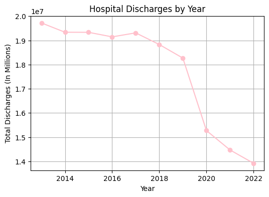

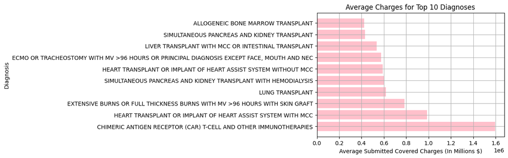

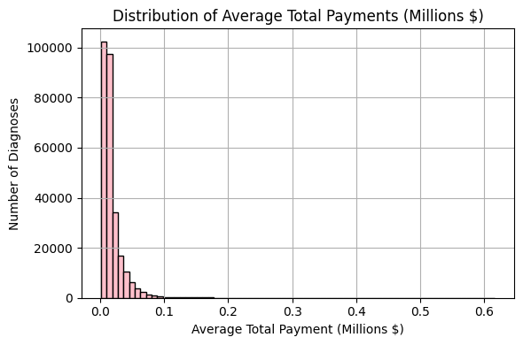

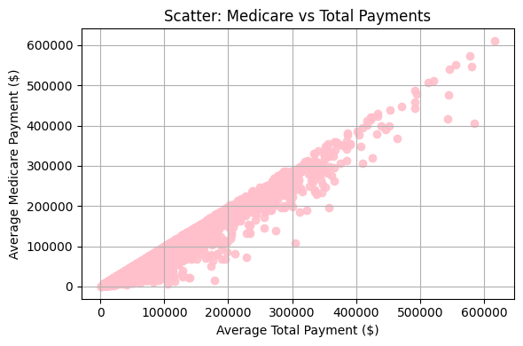

```python
# now i will organize and put the widgets directly over the plots they are affecting
# this includes interactives for the line plot, bar plot, histogram, and scatter plot
# i decided to group the filters by plot so that its clear with filter is affecting which plot
# this will be in a 2 by 2 grid

# organizing widgets and plots into columns

# top left diagnosis search
top_left = pn.Column(diagnosis_search, updated_discharges_plot)

# top right year dropdown
top_right = pn.Column(year_dropdown, updated_bar_plot)

# bottom left geographical search
bottom_left = pn.Column(state_select, updated_histogram)

# bottom right stacked sliders for scatter plot
#include total payment slider, total discharge slider, and total medicare slider
bottom_right = pn.Column(
    total_payment_slider,
    discharges_slider,
    medicare_payment_slider,
    updated_scatter_combined)

# arranging the columns into rows

# top row
top_row = pn.Row(top_left,
                 top_right,
                 sizing_mode="stretch_width")

# bottom row
bottom_row = pn.Row(bottom_left,
                    bottom_right,
                    sizing_mode="stretch_width")

# stack all of the rows into the dashboard layout
dashboard_layout = pn.Column(top_row,
                             bottom_row,
                             sizing_mode="stretch_both")
```

```python
# display dashboard
dashboard_layout.servable()
```